# Домашка №4

### Задание

Подгрузим пакеты, которые понадобятся вам для решения задачи.

```r
library(readr)
library(dplyr)
library(ggplot2)
library(tidyr)
library(tibble)
library(Metrics)
library(rsample)
library(fastDummies)
```

**Задача:**

У вас есть два набора данных: train (обучающий) и test (тестовый). В этих наборах есть три переменные: y, x1 и x2. Вам нужно обучить модель, которая будет предсказывать переменную y. Обучаете вы модель вы на train, а проверяете ее качество на test. В качестве меры качества возьмем MAE.

**План работы**:

1. Помните, что вы работаете только с датасетом train. На датасете test вы только проверяете качество вашей модели.
2. Попробуйте изучить ваши переменные. Какие они: числовые или категориальные? Попробуйте нарисовать график зависимости таргета (y) от признаков (x1, x2). Пострайтесь нанести все на один график, чтобы понять как устроена зависимость.
3. Постройте сначала примитивную модель (baseline), например константную. Посчитайте MAE и поймите много это или мало.
4. Постройте простую линейную регрессию. Посчитайте MAE. Лучше ли эта модель чем baseline? Нарисуйте график: по оси x прогноз, по оси y истинное значение. На этот же график нарисуйте биссектрису из точки (0, 0). Этот график поможет понять вам хорошо ли вы прогнозируете. На нем вы будете видеть систематические ошибки вашей модели.
5. Пытайтесь улучшить вашу модель, то есть уменьшить MAE на тестовом наборе как можно сильнее.
6. Лучшее MAE, которого можно достичь равно 3.92. То есть около 4.

### Решение

Подгрузим данные.

```r
train_url <- 'https://raw.githubusercontent.com/ahmedushka7/R/master/docs/homeworks/hw4/data/train.csv'
test_url <- 'https://raw.githubusercontent.com/ahmedushka7/R/master/docs/homeworks/hw4/data/test.csv'

train <- read_csv(train_url)
test <- read_csv(test_url)
```

Посмотрим какие переменные у нас есть. Видно, что есть 2 признака: $x_1$ и $x_2$.

```r
glimpse(train)
```

```
## Observations: 630
## Variables: 3
## $ y  <dbl> 198.96308, 21.00610, 120.75405, 119.81252, 100.67151, 194.012…
## $ x1 <dbl> -6.143569, -1.946033, -4.807728, -4.518801, -4.423903, -6.077…
## $ x2 <dbl> 1, 1, 1, 1, 1, 1, 1, 1, 1, 1, 1, 1, 1, 1, 1, 1, 1, 1, 1, 1, 1…
```

Первый признак числовой, а второй категориальный.

```r
train %>%
  count(x2)
```

```
## # A tibble: 3 x 2
##      x2     n
##   <dbl> <int>
## 1     1   217
## 2     2   199
## 3     3   214
```

Попробуем нарисовать зависимость нашего таргета от этих признаков.

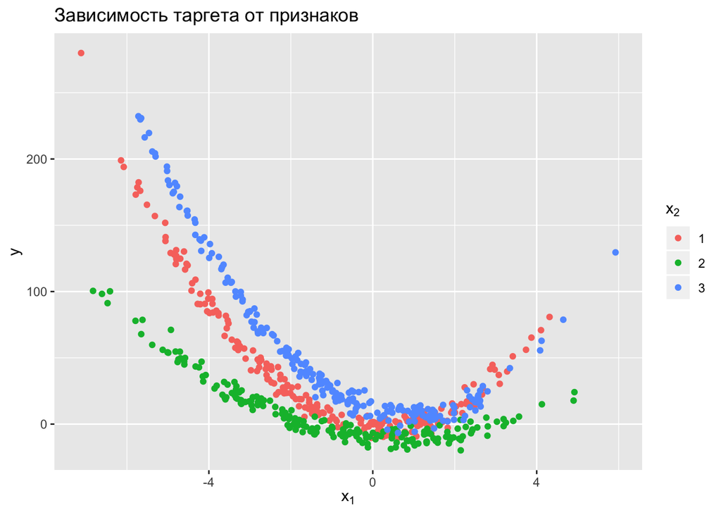

```r
ggplot(train, aes(x1, y, col = factor(x2))) +
  geom_point() +
  labs(x = quote(x[1]),
       col = quote(x[2]),
       title = 'Зависимость таргета от признаков')
```

Видна какая-то нелинейная, полиномиальная связь. Чем-то похоже на $x**2$. Поэтому можно будет взять полином второй степени дли переменной $x_1$. Также видно, что коэффициенты этого полинома различаются. Различаются они в зависимости от признака $x_2$.

Перед тем как делать “идеальную” модель, можно сделать простые.

**1. Среднее**

```r
MEAN <- mean(train$y)

train$predict1 <- MEAN
test$predict1 <- MEAN

mae(train$y, train$predict1)
```

```
## [1] 37.63236
```

```r
mae(test$y, test$predict1)
```

```
## [1] 36.64648
```

**2. Линейная регрессия без кодирования признака $x_2$**

```r
model2 <- lm(formula = y ~ x1 + x2, data = train)

train$predict2 <- predict(model2, train)
test$predict2 <- predict(model2, test)

mae(train$y, train$predict2)
```

```
## [1] 27.08195
```

```r
mae(test$y, test$predict2)
```

```
## [1] 28.4642
```

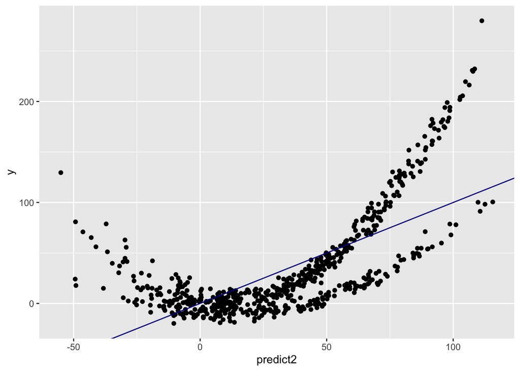

```r
ggplot(train, aes(predict2, y)) +
  geom_point() +
  geom_abline(color = 'darkblue')
```

**3. Полиномиальная модель без кодирования признака $x_2$**

```r
model3 <- lm(formula = y ~ poly(x1, degree = 2) + x2, data = train)

train$predict3 <- predict(model3, train)
test$predict3 <- predict(model3, test)

mae(train$y, train$predict3)
```

```
## [1] 18.00065
```

```r
mae(test$y, test$predict3)
```

```
## [1] 20.11781
```

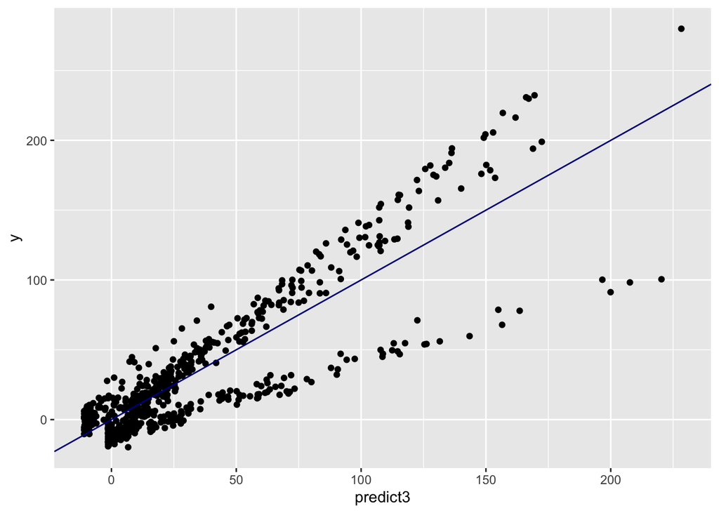

```r
ggplot(train, aes(predict3, y)) +
  geom_point() +
  geom_abline(color = 'darkblue')
```

**4.Полиномиальная модель с OHE**

```r
train <- dummy_cols(train, select_columns = 'x2')
test <- dummy_cols(test, select_columns = 'x2')

model4 <- lm(formula = y ~ poly(x1, 2) + x2_1 + x2_2 + x2_3 - 1,
             data = train)

train$predict4 <- predict(model4, train)
test$predict4 <- predict(model4, test)

mae(train$y, train$predict4)
```

```
## [1] 12.28784
```

```r
mae(test$y, test$predict4)
```

```
## [1] 13.69228
```

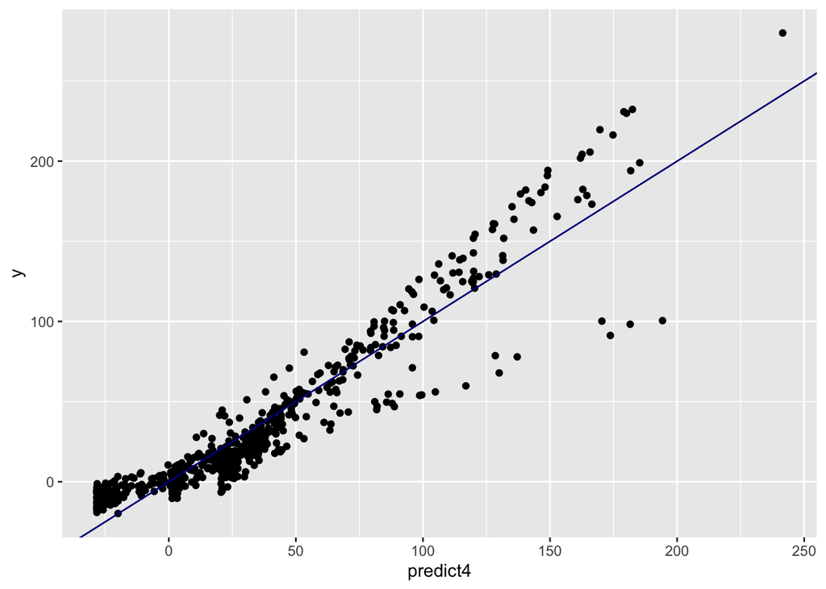

```r
ggplot(train, aes(predict4, y)) +
  geom_point() +
  geom_abline(color = 'darkblue')
```

**5. Полиномиальная модель с взаимодействием признаков.**

На графике выше мы видели, что зависимость полиномиальная, а также коэффициенты полинома зависят от переменной $x_2$.

$$w_0 + w_1 x + w_2 x^2$$
Коэффициенты $w_0, w_1, w_2$ различны для каждой категории переменной $x_2$. Категорий 3, коэффициентов тоже, поэтому при перемножении каждого с каждым, мы получим 9 переменных.

Скомбинируем дамми-переменные и $x_1$.

```r
train <- dummy_cols(train,  select_columns = 'x2',
                    remove_selected_columns = T)
test <- dummy_cols(test,  select_columns = 'x2',
                   remove_selected_columns = T)

train <- train %>%
  mutate(x12 = x1**2,
         x1_x21 = x1*x2_1,
         x1_x22 = x1*x2_2,
         x1_x23 = x1*x2_3,
         x12_x21 = x12*x2_1,
         x12_x22 = x12*x2_2,
         x12_x23 = x12*x2_3)

test <- test %>%
  mutate(x12 = x1**2,
         x1_x21 = x1*x2_1,
         x1_x22 = x1*x2_2,
         x1_x23 = x1*x2_3,
         x12_x21 = x12*x2_1,
         x12_x22 = x12*x2_2,
         x12_x23 = x12*x2_3)
```

А теперь построим модель. Не забываем улалиьть свободный коэффициент, чтобы у нас не возникло мультиколлинеарности.

```r
model5 <- lm(formula = y ~ x2_1 + x2_2 + x2_3 - 1 + x1_x21 + x1_x22 + x1_x23 + x12_x21 + x12_x22 + x12_x23,
             data = train)

model5
```

```
##
## Call:
## lm(formula = y ~ x2_1 + x2_2 + x2_3 - 1 + x1_x21 + x1_x22 + x1_x23 +
##     x12_x21 + x12_x22 + x12_x23, data = train)
##
## Coefficients:
##    x2_1     x2_2     x2_3   x1_x21   x1_x22   x1_x23  x12_x21  x12_x22
##  -2.220  -10.032   10.471   -2.887   -3.037   -9.677    5.024    2.035
## x12_x23
##   5.096
```

```r
train$predict5 <- predict(model5, train)
test$predict5 <- predict(model5, test)

mae(train$y, train$predict5)
```

```
## [1] 3.961937
```

```r
mae(test$y, test$predict5)
```

```
## [1] 3.919879
```

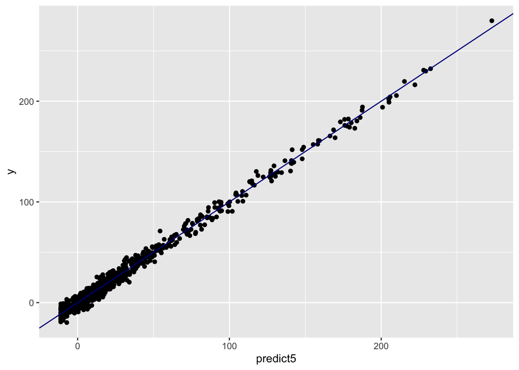

```r
ggplot(train, aes(predict5, y)) +
  geom_point() +
  geom_abline(color = 'darkblue')
```

Истинная зависимость, которую я генерировал, представлена ниже. Коэффициенты очень похожи.

```r
model5$coefficients
```

```
##       x2_1       x2_2       x2_3     x1_x21     x1_x22     x1_x23
##  -2.219866 -10.032301  10.470759  -2.886713  -3.037379  -9.676768
##    x12_x21    x12_x22    x12_x23
##   5.024268   2.035058   5.095651
```

```r
n <- 300

df1 <- tibble(x1 = seq(-5, 3, length.out = n) + rnorm(n),
              y = -2 + 5*x1^2 - 3*x1 + rnorm(n, sd = 5),
              x2 = 1)
df2 <- tibble(x1 = seq(-5, 3, length.out = n) + rnorm(n),
              y = -10 + 2*x1^2 - 3*x1 + rnorm(n, sd = 5),
              x2 = 2)
df3 <- tibble(x1 = seq(-5, 3, length.out = n) + rnorm(n),
              y = 10 + 5*x1^2 - 10*x1 + rnorm(n, sd = 5),
              x2 = 3)

df <- bind_rows(df1, df2, df3)
```